# Blueprint simulator

## Description

A script that simulates how long it takes to gather all blueprints. With options of starting from scratch, using existing filaments or a strategy to save filaments to buy the last remaining blueprints.

By default the simulation works based on previously observed probabilities which are:

- Common: 0.6
- Decent: 0.25
- Nifty: 0.1
- Splendid: 0.05

Additionally, the number of required hours is also based on measured timings in which on average 9.5 hours is needed to claim all six blueprints for one week.

Script works as the following:

1. Draws a random blueprint based on tier probabilities (also called an attempt)
2. If that blueprint has already been collected, then recycle it, if not keep it inventory
3. Spender strategy:
- Save up until get 7200 filaments (in order to buy any tier)
  - Unless total cost of missing is less than the tier cost above the cost of missing
- Buy a missing blueprint at random
- Reduce the amount of filament according to cost
- Continue to buy blueprints if filaments are still greater than 7200.
- If only one missing blueprint left then buy it
4. Hoarder strategy:
- Saves up all filaments from each recycling
- Calculate the total filament cost of remaining missing blueprints
- If saved up filaments is equal or greater then the remaining cost for missing blueprints, then stop as you now can buy the remaining blueprints
5. Print out the number of attempts, time and filaments required (if saving up).

A total of 528 blueprints ready to be claimed.

## Results

Ran using 1000 simulations per approach.

### Spender strategy

Average hours required: 1922

Average weeks required: 202

Average years required: 3.9

Average number of recycled blueprints: 844

### Hoarder strategy

Average hours required: 1770

Average weeks required: 186

Average years required: 3.6

Average number of recycled blueprints: 698

Average filament required for tipping point: 346K

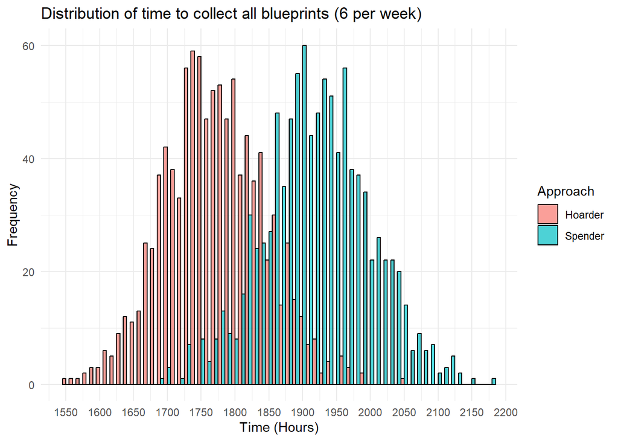

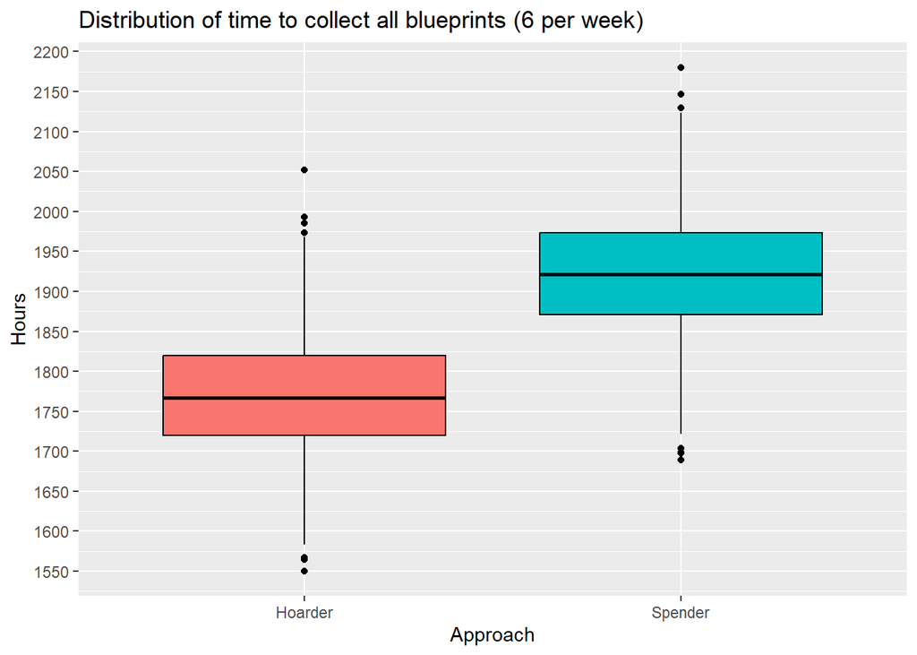

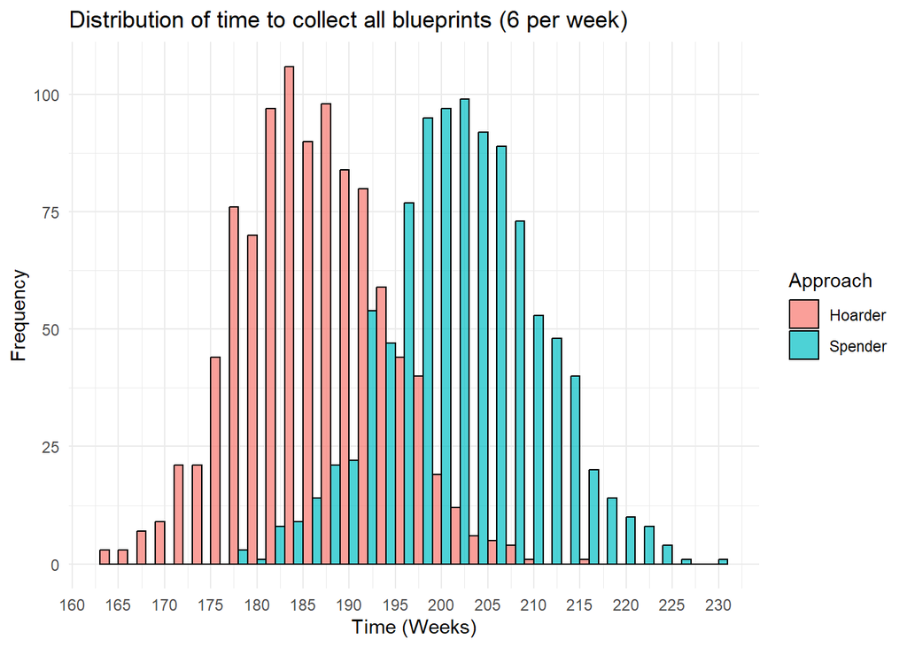

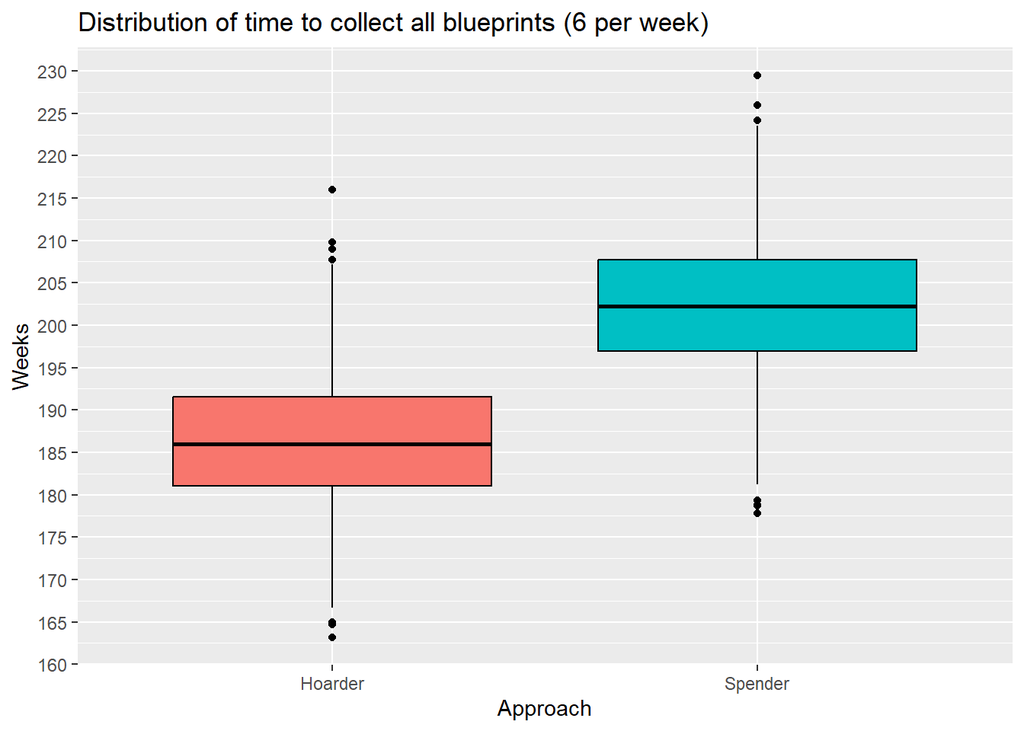

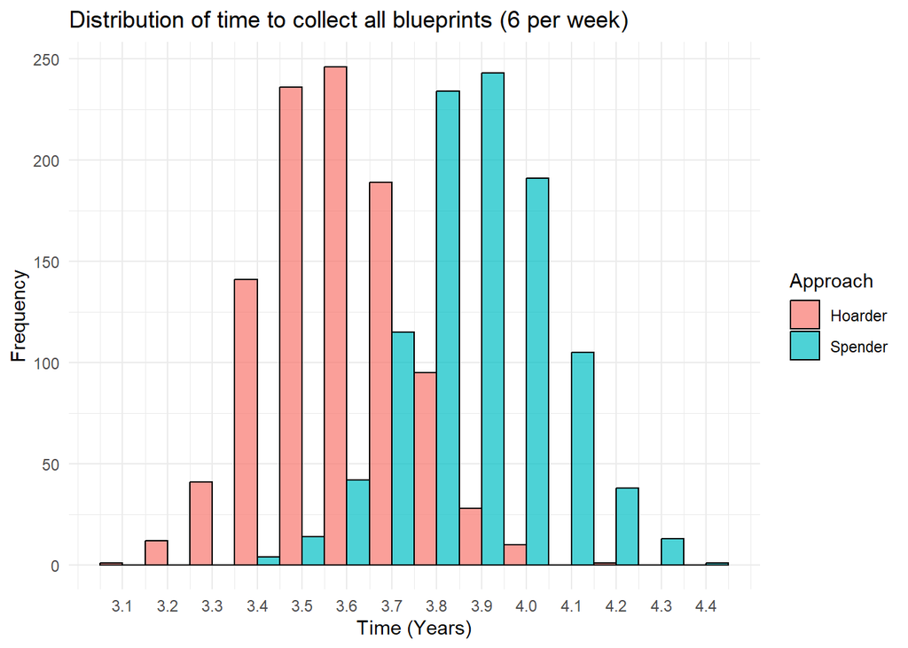

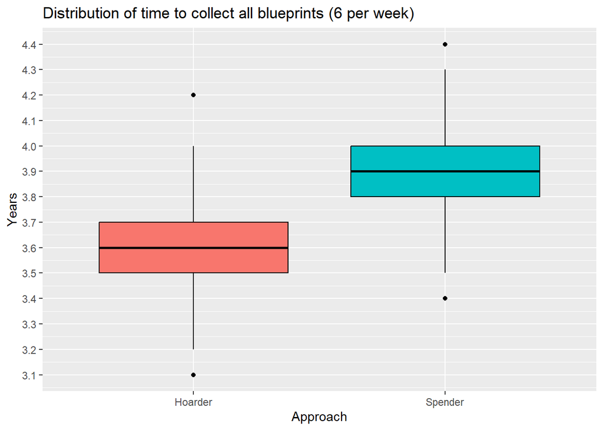

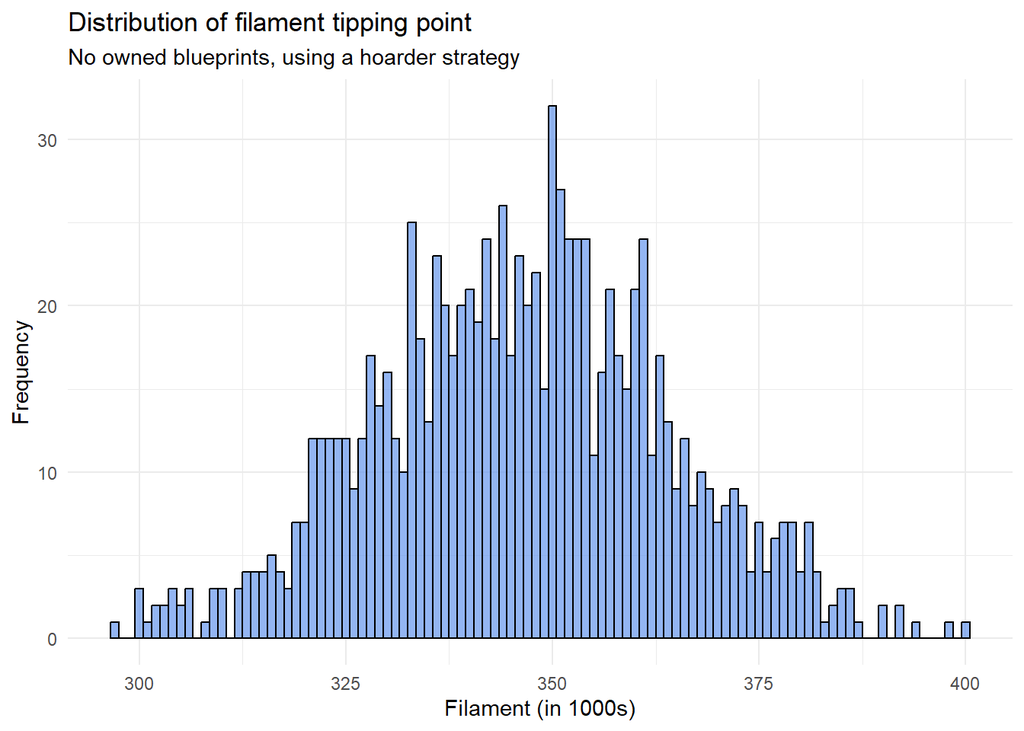

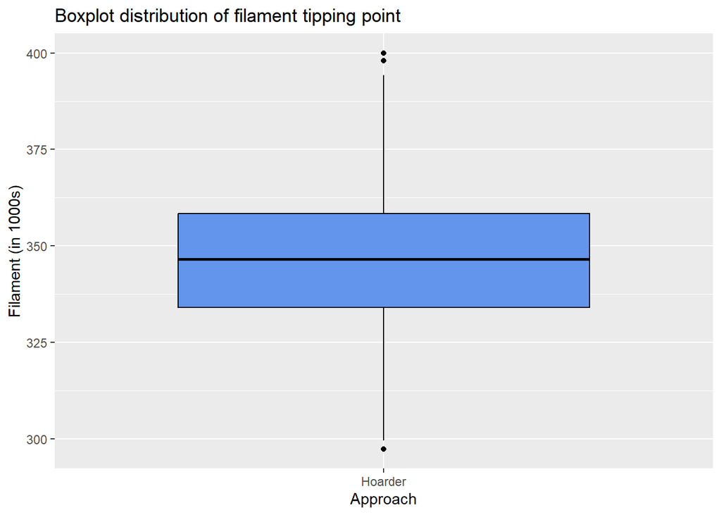